# Rotten or Fresh?

```python
%matplotlib inline
import pandas as pd
import numpy as np
import matplotlib.pyplot as plt

#hint: Consult the scikit-learn documentation to
#      learn about what these classes do do
from  sklearn.model_selection import cross_val_score
from sklearn.model_selection import train_test_split
from sklearn.naive_bayes import MultinomialNB
from sklearn.feature_extraction.text import CountVectorizer
import statsmodels.formula.api as smf
from sklearn.metrics import mean_squared_error
from sklearn.metrics import accuracy_score
from sklearn.preprocessing import StandardScaler
from sklearn.decomposition import PCA
from sklearn import preprocessing
from sklearn.model_selection import KFold
from sklearn.metrics import confusion_matrix
from sklearn.model_selection import cross_val_score
from sklearn.metrics import roc_auc_score, make_scorer
```

## Part 1: Descriptive analysis

Before beginning the "real" work, dig into the data a bit do see what you're dealing with. Begin by loading the datasets and dropping rows that have missing data:

```python
reviews = pd.read_csv('reviews.csv')
movies = pd.read_csv("movies.dat", delimiter='\t')

reviews = reviews[~reviews.quote.isnull()]
reviews = reviews[reviews.fresh != 'none']
reviews = reviews[reviews.quote.str.len() > 0]
```

### 1.1 Zooming in on a few reviewers

Results display top 30 critics with the most reviews, and their names in a table along with (a) the name of the publication they work for, (b) the date of their first review, and (c) the date of their last review

```python
# enter your code here

result_dictionary = dict()
second_result_dictionary = {}
top_30_critics = reviews.groupby(['critic'])['fresh'].count().reset_index(name='count').sort_values(['count'], ascending=False).head(30)
top30 = top_30_critics['critic']
filtered_top_30_critics_data_reviews = reviews.loc[reviews['critic'].isin(top30.values)]

group_by_publication = filtered_top_30_critics_data_reviews.groupby(['critic','publication'])
publications = list(group_by_publication.groups.keys())
for eachTuple in publications:
    result_dictionary[eachTuple[0]] = result_dictionary.get(eachTuple[0] , '') +  eachTuple[1] + ' '

for eachAuthor in top30.values:
    second_result_dictionary[eachAuthor] = {'start_Date' : '', 'end_Date' : ''}
    if 'publication' not in second_result_dictionary[eachAuthor]:
        publications = filtered_top_30_critics_data_reviews[filtered_top_30_critics_data_reviews['critic'] == eachAuthor]['publication'].unique()
        publications = np.apply_along_axis(lambda x: ', '.join(x), 0, publications)
        second_result_dictionary[eachAuthor]['publication'] = publications
    else:
        continue
```

```python
def first_last(df):
    return df.iloc[[0, -1]]

#filtered_top_30_critics_data_reviews.sort_values(['review_date'], ascending=True)

new_df = filtered_top_30_critics_data_reviews.groupby(['critic']).apply(lambda _df: _df.sort_values(by=['review_date'], ascending=True))

new_df = new_df.reset_index(drop=True)[['critic', 'review_date']]
new_df = new_df.groupby(['critic']).apply(first_last).reset_index(drop=True)[['critic', 'review_date']]

for index, row in new_df.iterrows():
    if index % 2 == 0:
        second_result_dictionary[row['critic']]['start_Date'] = pd.to_datetime(row['review_date']).date()
    else:
        second_result_dictionary[row['critic']]['end_Date'] = pd.to_datetime(row['review_date']).date()

result_df = pd.DataFrame.from_dict(second_result_dictionary, orient= 'index')
pd.set_option('max_colwidth', 1200)
result_df
```

|  | start_Date | end_Date | publication |
| --- | --- | --- | --- |
| Bosley Crowther | 2000-01-01 | 2008-05-06 | New York Times |
| Dave Kehr | 2000-01-01 | 2013-11-20 | Chicago Reader, New York Daily News, Chicago Tribune |
| Derek Adams | 2006-01-26 | 2009-10-04 | Time Out |
| Desson Thomson | 2000-01-01 | 2012-10-08 | Washington Post |
| Edward Guthmann | 2000-01-01 | 2003-04-04 | San Francisco Chronicle |
| Emanuel Levy | 2000-01-01 | 2010-08-06 | Variety |
| Geoff Andrew | 2005-08-11 | 2012-04-05 | Time Out |
| Hal Hinson | 2000-01-01 | 2013-06-26 | Washington Post |
| James Berardinelli | 1800-01-01 | 2012-02-07 | ReelViews |
| Janet Maslin | 2000-01-01 | 2010-09-07 | New York Times |
| Joe Baltake | 2000-01-01 | 2013-08-04 | Sacramento Bee, Passionate Moviegoer, Philadelphia Daily News |
| Jonathan Rosenbaum | 1988-07-11 | 2013-10-22 | Chicago Reader |
| Kenneth Turan | 2000-01-01 | 2013-10-05 | Los Angeles Times |
| Kevin Thomas | 2000-01-01 | 2013-11-02 | Los Angeles Times |
| Liam Lacey | 2001-08-24 | 2012-04-04 | Globe and Mail |
| Lisa Schwarzbaum | 1979-01-01 | 2012-08-15 | Entertainment Weekly |
| Michael Wilmington | 2000-01-01 | 2013-11-21 | Chicago Tribune, Los Angeles Times |
| Mick LaSalle | 2000-01-01 | 2009-11-25 | San Francisco Chronicle |
| Owen Gleiberman | 1800-01-01 | 2011-09-07 | Entertainment Weekly |
| Peter Stack | 2000-01-01 | 2002-06-18 | San Francisco Chronicle |
| Richard Corliss | 2003-12-16 | 2013-11-06 | TIME Magazine |
| Richard Schickel | 2000-01-01 | 2013-08-05 | TIME Magazine, The Atlantic |
| Rick Groen | 2002-03-19 | 2009-08-14 | Globe and Mail |
| Rita Kempley | 2000-01-01 | 2013-11-02 | Washington Post |
| Roger Ebert | 2000-01-01 | 2013-06-11 | Chicago Sun-Times, At the Movies |
| Stephen Holden | 2000-01-01 | 2009-02-06 | New York Times |
| Susan Stark | 2000-01-01 | 2002-10-25 | Detroit News |
| Todd McCarthy | 2000-01-01 | 2012-10-09 | Variety |
| Variety Staff | 2001-02-13 | 2012-08-15 | Variety |
| Vincent Canby | 2000-01-01 | 2013-07-29 | New York Times |

### 1.2 Ratings over time

```python
# enter your code here
movies = pd.read_csv("movies.dat", delimiter='\t')

#removing bad data from rtAllCriticsRating
movies = movies[(movies.rtAllCriticsRating != "\\N")]
movies.columns
```

```
Index(['id', 'title', 'imdbID', 'spanishTitle', 'imdbPictureURL', 'year',
       'rtID', 'rtAllCriticsRating', 'rtAllCriticsNumReviews',
       'rtAllCriticsNumFresh', 'rtAllCriticsNumRotten', 'rtAllCriticsScore',
       'rtTopCriticsRating', 'rtTopCriticsNumReviews', 'rtTopCriticsNumFresh',
       'rtTopCriticsNumRotten', 'rtTopCriticsScore', 'rtAudienceRating',
       'rtAudienceNumRatings', 'rtAudienceScore', 'rtPictureURL'],
      dtype='object')
```

```python
def toFloat(value):
    return float(value)

movies.rtAllCriticsRating = movies.rtAllCriticsRating.apply(toFloat)
#drop movies with rtAllCriticsRating rating = 0
movies = movies[(movies.rtAllCriticsRating > 0.0)]
movies.rtAllCriticsRating.astype('float')
movies.shape
```

```
(7752, 21)
```

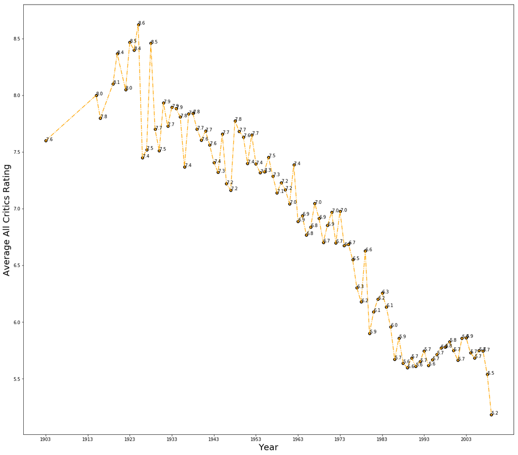

```python
rating_over_years_series = movies.groupby(['year'])['rtAllCriticsRating'].mean()
fig, ax = plt.subplots(figsize= (20,18))
x = rating_over_years_series.index
y = rating_over_years_series.values
ax.scatter(x, y, color = "black")
for i, year in enumerate(rating_over_years_series.index):
    ax.annotate(str(round(y[i],1)), (x[i], y[i]), fontsize=10)
x_labels = range(min(x), max(x)+1, 10)
plt.xticks(x_labels)
ax.set(xlabel = 'Year', ylabel = 'Average All Critics Rating')
ax.yaxis.label.set_size(20)
ax.xaxis.label.set_size(20)
ax.plot(x, y , c= "orange", marker='.', linestyle='-.')
plt.show()
```

From the graph it is clear that the average critic rating has been declining with the movie release year.It means that critics rate old movies higher than the recent movies.

## Part 2: Naive Bayes

### Using CountVectorizer

```python
from sklearn.feature_extraction.text import CountVectorizer

text = ['machine learning rocks', 'machine learning rules', 'rocks rocks rules']
print("Original text is", '\n'.join(text))

vectorizer = CountVectorizer(min_df=0)

# call `fit` to build the vocabulary
vectorizer.fit(text)

# call `transform` to convert text to a bag of words
x = vectorizer.transform(text)

# CountVectorizer uses a sparse array to save memory, but it's easier in this assignment to
# convert back to a "normal" numpy array
x = x.toarray()

print("Transformed text vector is", x)

# `get_feature_names` tracks which word is associated with each column of the transformed x
print("Words for each feature:")
print(vectorizer.get_feature_names())
```

```
Original text is machine learning rocks
machine learning rules
rocks rocks rules
Transformed text vector is [[1 1 1 0]
 [1 1 0 1]
 [0 0 2 1]]
Words for each feature:
['learning', 'machine', 'rocks', 'rules']
```

```python
#remove items with no review text
reviews = reviews[reviews.quote != '']
print(reviews.shape)
```

```
(13419, 9)
```

```python
"""
Function
--------
make_xy

Build a bag-of-words training set for the review data

Parameters
-----------
reviews : Pandas DataFrame
    The review data from above

vectorizer : CountVectorizer object (optional)
    A CountVectorizer object to use. If None,
    then create and fit a new CountVectorizer.
    Otherwise, re-fit the provided CountVectorizer
    using the reviews data

Returns
-------
X : numpy array (dims: nreview, nwords)
    Bag-of-words representation for each review.
Y : numpy array (dims: nreview)
    1/0 array. 1 = fresh review, 0 = rotten review

Examples
--------
X, Y = make_xy(reviews)
"""
def make_xy(reviews, vectorizer=None):
    #Your code here
    vectorizer.fit(reviews['quote'])
    X = vectorizer.transform(reviews['quote']).toarray()
    le = preprocessing.LabelEncoder()
    le.fit(reviews['fresh'].unique())
    le.classes_ = ['rotten', 'fresh']
    encoded_target = pd.Series(le.transform(reviews['fresh']))
    Y = encoded_target.values
    return X, Y
```

```python
X, Y = make_xy(reviews, CountVectorizer())
print(X.shape, Y.shape)
```

```
(13419, 20875) (13419,)
```

### 2.2 Test-Train split

```python
# enter your code here
X_train, X_test, Y_train, Y_test = train_test_split(X, Y, test_size=0.33, random_state=48)
```

### 2.3 Naive Bayes with `MultinomialNB`

```python
# enter your code here
# call the fitted model fitted_model, for future reference:
fitted_model = MultinomialNB()
c = fitted_model.fit(X_train, Y_train)

print("Accuracy score on Training data set is ",c.score(X_train, Y_train))
print("Accuracy score on Test data set is",c.score(X_test, Y_test))
```

```
Accuracy score on Training data set is  0.9202447163515016
Accuracy score on Test data set is 0.782343644163468
```

We see a large difference between model accuracy on the Training Data set and the Test Data set. The accuracy on Training data is 92% while only 78% on the Training Data. This means that our model performs very well on Training data but not so good on the test data, which means that our model is overfitting!

## Part 3: Evaluation

### 3.1 Estimate the likelihood of your data

```python
"""
Function
--------
log_likelihood

Compute the log likelihood of a dataset according to a bayesian classifier.
The Log Likelihood is defined by

L = Sum_fresh(logP(fresh)) + Sum_rotten(logP(rotten))

Where Sum_fresh indicates a sum over all fresh reviews,
and Sum_rotten indicates a sum over rotten reviews

Parameters
----------
model : Bayesian classifier
x : (nexample, nfeature) array
    The input data
y : (nexample) integer array
    Whether each review is Fresh
"""

def log_likelihood(model, x, y):
    prob = model.predict_log_proba(x)
    rotten = y == 0
    fresh = ~rotten
    return prob[rotten, 0].sum() + prob[fresh, 1].sum()

# output the likelihood of your test data (example - you may need to
# chance the nambes of the variables below to match your code in 2.2 and 2.3
log_likelihood(c, X_test, Y_test)
```

```
-2377.733802547393
```

### 3.2 Cross-Validation

Our classifier has a few hyperparameters. The two most important are:

1. The `min_df` keyword in `CountVectorizer`, which will ignore words which appear in fewer than `min_df` fraction of reviews. Words that appear only once or twice can lead to overfitting, since words which occur only a few times might correlate very well with Fresh/Rotten reviews by chance in the training dataset.
2. The [`alpha` keyword](http://scikit-learn.org/stable/modules/naive_bayes.html#multinomial-naive-bayes) in the Bayesian classifier is a "smoothing parameter" -- increasing the value decreases the sensitivity to any single feature, and tends to pull prediction probabilities closer to 50%.

```python
#suppress warnings
def warn(*args, **kwargs):
    pass
import warnings
warnings.warn = warn

#the grid of parameters to search over
alphas = [0, .1, 1, 5, 10, 50]
min_dfs = [1e-5, 1e-4, 1e-3, 1e-2, 1e-1]

#Find the best value for alpha and min_df, and the best classifier
best_alpha = None
best_min_df = None
max_loglike = -np.inf


for alpha in alphas:
    for min_df in min_dfs:
        vectorizer = CountVectorizer(min_df = min_df)
        X, Y = make_xy(reviews, vectorizer)
        X_train_new, X_test_new, Y_train_new, Y_test_new = train_test_split(X, Y, test_size=0.33, random_state =48)
        fitted_model_new = MultinomialNB(alpha = alpha)
        score = cross_val_score(fitted_model_new, X_train_new, Y_train_new, scoring = log_likelihood, cv=KFold(n_splits=5))
        mean_score = score.mean()
        if mean_score > max_loglike:
            max_loglike = mean_score
            best_alpha = alpha
            best_min_df = min_df

print('The best score is ', max_loglike, 'for alpha :' , best_alpha, 'and min_df :', best_min_df)
```

```
The best score is  -987.8344940544542 for alpha : 5 and min_df : 0.001
```

The best score is -987.8344940544542 for alpha : 5 and min_df : 0.001

```python
#Enter your code here
def warn(*args, **kwargs):
    pass
import warnings
warnings.warn = warn

vectorizer_best = CountVectorizer(lowercase=True, stop_words='english', min_df=best_min_df)
X_best , Y_best = make_xy(reviews, vectorizer_best)

X_train_best, X_test_best, Y_train_best, Y_test_best = train_test_split(X_best, Y_best, test_size=0.33, random_state=48)

best_fitted_model = MultinomialNB(alpha = best_alpha)
best_fitted_model.fit(X_train_best, Y_train_best)

print("Accuracy score on Training data set is ",best_fitted_model.score(X_train_best, Y_train_best))
print("Accuracy score on Test data set is",best_fitted_model.score(X_test_best, Y_test_best))
```

```
Accuracy score on Training data set is  0.7817575083426029
Accuracy score on Test data set is 0.7376382930684128
```

Using cross validation, we see that the best value for alpha and min df is 5 and 0.001 respectively. We use these values for training a new NB model. Our new model accuracy on training data is 0.78 and the accuracy on test data is 0.74. This is significantly different from the previous model's scores (without cross validation and hyperparameters tuning). Now there isn't a significant difference between the training accuracy and test accuracy on our new model,thus, we can say that the new model does not overfit and is better than our previous model.

### Using classification accuracy

```python
#suppress warnings
def warn(*args, **kwargs):
    pass
import warnings
warnings.warn = warn

#the grid of parameters to search over
alphas = [0, .1, 1, 5, 10, 50]
min_dfs = [1e-5, 1e-4, 1e-3, 1e-2, 1e-1]

#Find the best value for alpha and min_df, and the best classifier
best_alpha = None
best_min_df = None
max_roc_auc_score = -np.inf


for alpha in alphas:
    for min_df in min_dfs:
        vectorizer = CountVectorizer(min_df = min_df)
        X, Y = make_xy(reviews, vectorizer)
        X_train_new, X_test_new, Y_train_new, Y_test_new = train_test_split(X, Y, test_size=0.33, random_state =48)
        fitted_model_new = MultinomialNB(alpha = alpha)
        score = cross_val_score(fitted_model_new, X_train_new, Y_train_new, scoring = make_scorer(roc_auc_score), cv=KFold(n_splits=5))
        mean_score = score.mean()
        if mean_score > max_roc_auc_score:
            max_roc_auc_score = mean_score
            best_alpha = alpha
            best_min_df = min_df

print('The best score is ', max_roc_auc_score, 'for alpha :' , best_alpha, 'and min_df :', best_min_df)
```

```
The best score is  0.740521406589432 for alpha : 1 and min_df : 0.0001
```

```python
vectorizer_best_roc = CountVectorizer(lowercase=True, stop_words='english', min_df=best_min_df)
X_best , Y_best = make_xy(reviews, vectorizer_best_roc)

X_train_best, X_test_best, Y_train_best, Y_test_best = train_test_split(X_best, Y_best, test_size=0.33, random_state=48)

best_fitted_model_roc = MultinomialNB(alpha = best_alpha)
best_fitted_model_roc.fit(X_train_best, Y_train_best)

print("Accuracy score on Training data set is ",best_fitted_model_roc.score(X_train_best, Y_train_best))
print("Accuracy score on Test data set is",best_fitted_model_roc.score(X_test_best, Y_test_best))
```

```
Accuracy score on Training data set is  0.906896551724138
Accuracy score on Test data set is 0.7739896139083314
```

The accuracy on the training set has increased while there is no significant improvement on the test accuracy. We have an overfit model(large difference in the training accuracy and test accuracy).

### 3.3 Interpretation

```python
from IPython.display import Markdown, display
def printmd(string):
    display(Markdown("**" + string + "**"))
```

```python
# Enter your code here
features = pd.DataFrame(np.array(vectorizer_best.get_feature_names()))
features.rename(columns={0:'words'}, inplace =True)
features.tail()
```

|  | words |
| --- | --- |
| 1938 | yes |
| 1939 | york |
| 1940 | young |
| 1941 | youth |
| 1942 | zone |

```python
iden_matrix = np.identity(np.shape(features)[0])
probabilities = best_fitted_model.predict_log_proba(iden_matrix)
features['probability_rotten'] = probabilities[ : , 0]
features['probability_fresh'] = probabilities[ : , 1]
words_best_predict_rotten_df = features.sort_values('probability_rotten', ascending=False)[['words', 'probability_rotten']].head(10)
words_best_predict_rotten = ', '.join(words_best_predict_rotten_df['words'].tolist())


printmd('The 10 words that best predict a "Rotten" review are : ' + words_best_predict_rotten)

words_best_predict_fresh_df = features.sort_values('probability_fresh', ascending=False)[['words', 'probability_fresh']].head(10)
words_best_predict_fresh = ', '.join(words_best_predict_fresh_df['words'].tolist())

printmd('The 10 words that best predict a "Fresh" review are : ' + words_best_predict_fresh)
```

**The 10 words that best predict a "Rotten" review are : unfortunately, lame, bland, uninspired, pointless, disappointment, sadly, dull, problem, mechanical**

**The 10 words that best predict a "Fresh" review are : masterpiece, superb, delight, extraordinary, intelligent, touching, beautifully, remarkable, entertaining, smart**

### 3.4 Error Analysis

5 fresh and rotten reviews where your model performs particularly poorly.

```python
X, Y = make_xy(reviews, CountVectorizer(min_df = 0.001))

X_train, X_test, Y_train, Y_test = train_test_split(X, Y, test_size=0.33, random_state=48)

best_fitted_model.fit(X_train, Y_train)

prob = best_fitted_model.predict_proba(X_train)[:, 0]
prob
```

```
array([0.82450298, 0.07301105, 0.35610232, ..., 0.10941595, 0.08133111,
       0.0638925 ])
```

```python
predict = best_fitted_model.predict(X_train)
```

```python
poor_rotten = np.argsort(prob[Y_train == 0])[:5]
poor_fresh = np.argsort(prob[Y_train == 1])[-5:]
```

```python
for row in poor_fresh:
    print(reviews[Y == 0].quote.iloc[row] + '\n')
```

```
Director Lou Adler (the record producer) finds a few chuckles, but mostly it's amateur night.

This is the kind of movie where the filmmaker hopes to shock you with sickening carnage and violent amorality, while at the same time holding himself carefully aloof from it with his style.

The Whole Ten Yards is not as desperate, unfunny, and nonsensical as its title. It's worse.

Incidentally, it's a bad idea to try bailing out hopelessly flat comedy with outtakes that are funnier than the in-takes manage to be.

Empty glitz in search of a style.
```

```python
for row in poor_fresh:
    print(reviews[Y == 1].quote.iloc[row] + '\n')
```

```
Director Margarethe von Trotta effortlessly weaves history and personal events into a tapestry full of emotion and irony.

New insignts about Anne's spicy personality and immense curiosity are revealed by Holocaust survivors Hanneli Goslar and particularly Miep Gies, an office employee of Anne's father who was one of the main helpers to the families in hiding.

Visually enchanting.

While the film remains a respectable thriller, only Ryan's crafty, quietly deranged performance lifts it out of the ordinary.

On Golden Pond is a mixed blessing, but it offers one performance of rare quality and three others that are very good. That's not half-bad.
```